# Introduction

christianbomholt

September 24, 2018

## Avocado prices

> The table below represents weekly 2018 retail scan data for National retail volume (units) and price. Retail scan data comes directly from retailers’ cash registers based on actual retail sales of Hass avocados. Starting in 2013, the table below reflects an expanded, multi-outlet retail data set. Multi-outlet reporting includes an aggregation of the following channels: grocery, mass, club, drug, dollar and military. The Average Price (of avocados) in the table reflects a per unit (per avocado) cost, even when multiple units (avocados) are sold in bags. The Product Lookup codes (PLU’s) in the table are only for Hass avocados. Other varieties of avocados (e.g. greenskins) are not included in this table.

Some relevant columns in the dataset:

Date - The date of the observation AveragePrice - the average price of a single avocado type - conventional or organic year - the year Region - the city or region of the observation Total Volume - Total number of avocados sold 4046 - Total number of avocados with PLU 4046 sold 4225 - Total number of avocados with PLU 4225 sold 4770 - Total number of avocados with PLU 4770 sold

## Import data

```r
avocadoCSV <- "../data/avocado.csv"

avocadoDF <- read.csv(avocadoCSV)[,-1]
head(avocadoDF, 10)
```

```
##          Date AveragePrice Total.Volume   X4046     X4225  X4770
## 1  2015-12-27         1.33     64236.62 1036.74  54454.85  48.16
## 2  2015-12-20         1.35     54876.98  674.28  44638.81  58.33
## 3  2015-12-13         0.93    118220.22  794.70 109149.67 130.50
## 4  2015-12-06         1.08     78992.15 1132.00  71976.41  72.58
## 5  2015-11-29         1.28     51039.60  941.48  43838.39  75.78
## 6  2015-11-22         1.26     55979.78 1184.27  48067.99  43.61
## 7  2015-11-15         0.99     83453.76 1368.92  73672.72  93.26
## 8  2015-11-08         0.98    109428.33  703.75 101815.36  80.00
## 9  2015-11-01         1.02     99811.42 1022.15  87315.57  85.34
## 10 2015-10-25         1.07     74338.76  842.40  64757.44 113.00
##    Total.Bags Small.Bags Large.Bags XLarge.Bags         type year region
## 1     8696.87    8603.62      93.25           0 conventional 2015 Albany
## 2     9505.56    9408.07      97.49           0 conventional 2015 Albany
## 3     8145.35    8042.21     103.14           0 conventional 2015 Albany
## 4     5811.16    5677.40     133.76           0 conventional 2015 Albany
## 5     6183.95    5986.26     197.69           0 conventional 2015 Albany
## 6     6683.91    6556.47     127.44           0 conventional 2015 Albany
## 7     8318.86    8196.81     122.05           0 conventional 2015 Albany
## 8     6829.22    6266.85     562.37           0 conventional 2015 Albany
## 9    11388.36   11104.53     283.83           0 conventional 2015 Albany
## 10    8625.92    8061.47     564.45           0 conventional 2015 Albany
```

## Vizualize general dynamics

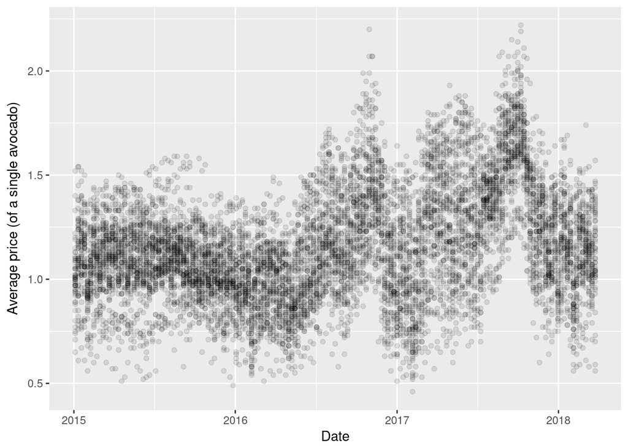

```r
library(ggplot2)
library(dplyr)
ggplot(data = avocadoDF %>% filter(type=="conventional") %>%
         mutate(Date=as.Date(Date))) +
  geom_point(mapping = aes(x = Date, y = AveragePrice), alpha = 5/50) +
  xlab("Date") +
  ylab("Average price (of a single avocado)")
```

```r
avocadoCSV_subset <- "../data/subset_avocado.csv"

avocadoDF_subset <- read.csv(avocadoCSV_subset)[,-1]
xtabs(AveragePrice~region+type,avocadoDF_subset)
```

```
##                      type
## region                conventional organic
##   Albany                      5.68    9.21
##   Atlanta                     5.28    8.77
##   BaltimoreWashington         5.74    6.48
##   Boise                       5.21    7.77
##   Boston                      5.74    9.56
##   BuffaloRochester            7.29    8.11
```

## More advanced cross-tabbing

```r
xt <- xtabs(AveragePrice~region+type,
            aggregate(AveragePrice~region+type,avocadoDF,mean))
```

## Linear models

```r
model <- lm(AveragePrice ~ as.numeric(as.Date(Date)),avocadoDF)
summary(model)
```

```
##
## Call:
## lm(formula = AveragePrice ~ as.numeric(as.Date(Date)), data = avocadoDF)
##
## Residuals:
##      Min       1Q   Median       3Q      Max
## -1.00081 -0.29551 -0.04596  0.25120  1.83081
##
## Coefficients:
##                             Estimate Std. Error t value Pr(>|t|)
## (Intercept)               -1.515e+00  1.471e-01  -10.30   <2e-16 ***
## as.numeric(as.Date(Date))  1.716e-04  8.636e-06   19.87   <2e-16 ***
## ---
## Signif. codes:  0 '***' 0.001 '**' 0.01 '*' 0.05 '.' 0.1 ' ' 1
##
## Residual standard error: 0.3984 on 18247 degrees of freedom
## Multiple R-squared:  0.02117,    Adjusted R-squared:  0.02112
## F-statistic: 394.7 on 1 and 18247 DF,  p-value: < 2.2e-16
```

```r
library(broom)
tidy(summary(model))
```

```
##                        term      estimate    std.error statistic
## 1               (Intercept) -1.5154241193 1.470721e-01 -10.30395
## 2 as.numeric(as.Date(Date))  0.0001715749 8.635857e-06  19.86773
##        p.value
## 1 7.910002e-25
## 2 6.418499e-87
```

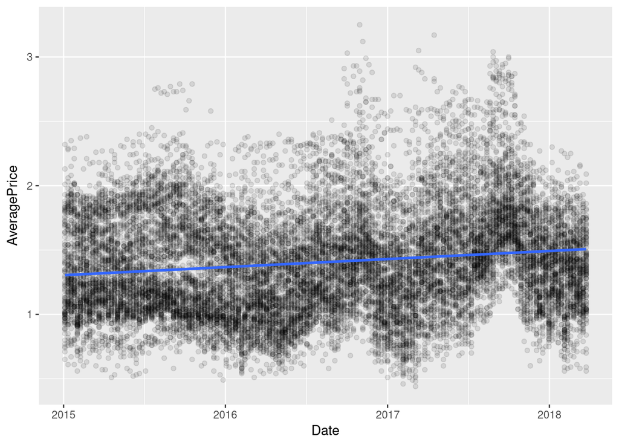

```r
avocadoDF$Date <- avocadoDF$Date %>% as.Date()
ggplot(avocadoDF,aes(Date,AveragePrice))+
  geom_point(alpha = 5/50)+
  geom_smooth(method='lm')
```

## Measuring runtime

```r
system.time(gaussianMean<-mean(rnorm(10000)))
```

```
##    user  system elapsed
##   0.000   0.000   0.001
```

```r
 ?proc.time
```

> The first two entries are the total user and system CPU times of the current R process and any child processes on which it has waited, and the third entry is the ‘real’ elapsed time since the process was started.

> The definition of ‘user’ and ‘system’ times is from your OS. Typically it is something like *The ‘user time’ is the CPU time charged for the execution of user instructions of the calling process. The ‘system time’ is the CPU time charged for execution by the system on behalf of the calling process.*

## Read from SQL

```r
library(DBI)
library(RSQLite)
con <- dbConnect(SQLite(), dbname="../data/flight_data/airports.sqlite")
dbReadTable(con, "avocados") %>% head
```

```
##         Date AveragePrice Total.Volume   X4046     X4225  X4770 Total.Bags
## 1 2015-12-27         1.33     64236.62 1036.74  54454.85  48.16    8696.87
## 2 2015-12-20         1.35     54876.98  674.28  44638.81  58.33    9505.56
## 3 2015-12-13         0.93    118220.22  794.70 109149.67 130.50    8145.35
## 4 2015-12-06         1.08     78992.15 1132.00  71976.41  72.58    5811.16
## 5 2015-11-29         1.28     51039.60  941.48  43838.39  75.78    6183.95
## 6 2015-11-22         1.26     55979.78 1184.27  48067.99  43.61    6683.91
##   Small.Bags Large.Bags XLarge.Bags         type year region
## 1    8603.62      93.25           0 conventional 2015 Albany
## 2    9408.07      97.49           0 conventional 2015 Albany
## 3    8042.21     103.14           0 conventional 2015 Albany
## 4    5677.40     133.76           0 conventional 2015 Albany
## 5    5986.26     197.69           0 conventional 2015 Albany
## 6    6556.47     127.44           0 conventional 2015 Albany
```